# Matplotlib for Visualization

## Matplotlib

Matplotlib is a plotting library for the Python programming language and its numerical mathematics extension NumPy.

It provides an object-oriented API for embedding plots into applications using general-purpose GUI toolkits like Tkinter, wxPython, Qt, or GTK.

```python
import matplotlib.pyplot as plt
```

```python
x = [10,20,30,40,50]
y = [2,3,6,54,3]
```

## Bar chart: 2 variables

categorical variable and continuous variable

continuous variable and continuous variable

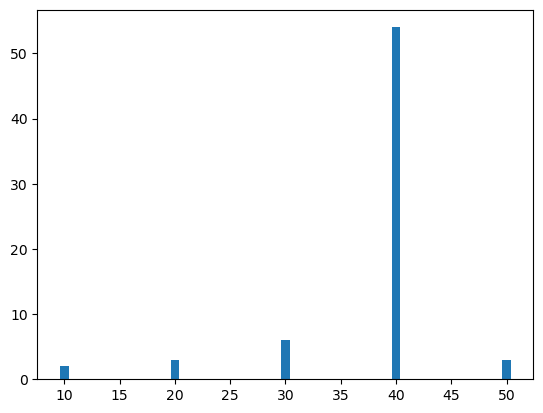

```python
plt.bar(x,y)
plt.show()
```

## Horizontal Bar chart

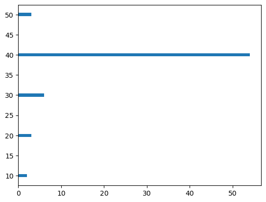

```python
plt.barh(x,y)
plt.show()
```

```python
fruits = ["Apple","Banana","Pineapple"]
calories = [35,55,28]
```

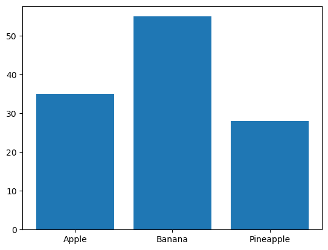

```python
plt.bar(fruits,calories)
plt.show()
```

### If you wanna show labels to the bars use bar_label method

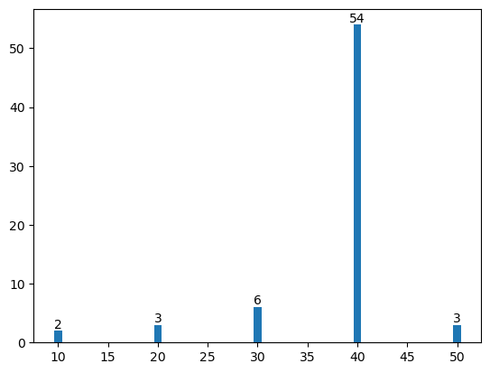

```python
bars = plt.bar(x,y)
plt.bar_label(bars)
plt.show()
```

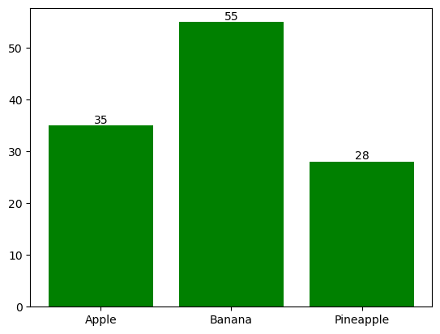

```python
fruit_bars = plt.bar(fruits,calories,color='g')
plt.bar_label(fruit_bars)
plt.show()
```

## Pie Chart helps in understanding the proportion of variable as a whole.

Pie charts need one categorical variable and one continuous variable

categorical variable should contain minimal unique values. If the unique values are high, slices are proportional to number of unique values, so ithe pie chart will not look good. Analysis will not be easy

```python
x
```

```
[10, 20, 30, 40, 50]
```

```python
p = ['Alpha','Beta','Theta','Gamma','Yamma']
```

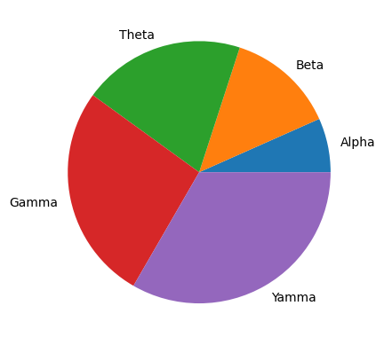

```python
plt.pie(x,labels=p)
plt.show()
```

TO show the slices of pie in percentages of whole: use autopct='%1.1f%%'

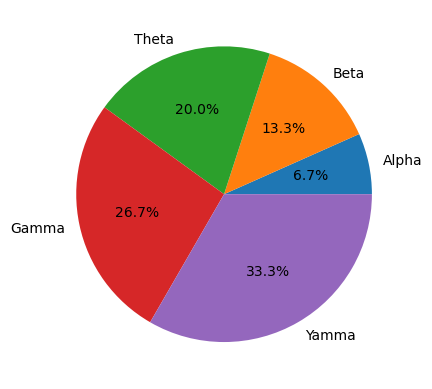

```python
plt.pie(x,labels=p,autopct='%1.1f%%') # will display percentage with 1 decimal point
plt.show()
```

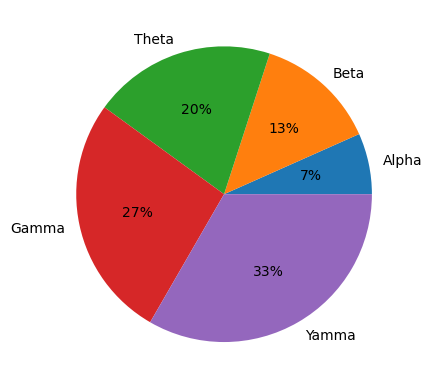

```python
plt.pie(x,labels=p,autopct='%.0f%%') # will display percentage rounded up
plt.show()
```

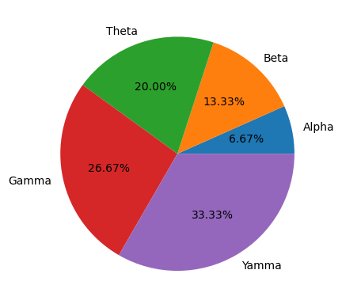

```python
plt.pie(x,labels=p,autopct='%1.2f%%') # will display percentage with 2 decimal point
plt.show()
```

## Line chart are helpful in identifying trends or patterns over time

Line charts are preferred mostly for date related data

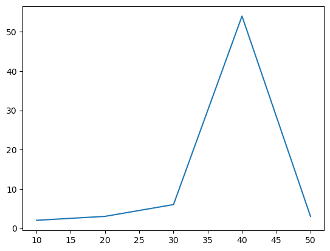

```python
plt.plot(x,y)
```

```python
z = [4,5,7,19,20]
```

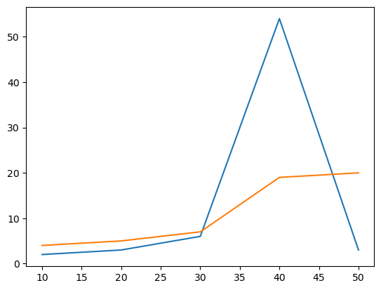

```python
plt.plot(x,y)
plt.plot(x,z)
plt.show()
```

## Scatter plot helps in understanding relationships between 2 variables.

Scatter plot is plotted between 2 continuous variables/features

1. Helps in identifying linear relationships between 2 numerical features => are the features corelated to each other or not with the change in 1 feature will the other feature change or not
2. Identify Clusters /Gropus of data between 2 numerical features, for grouping mention one categorical feature

```python
print(x,y)
```

```
[10, 20, 30, 40, 50] [2, 3, 6, 54, 3]
```

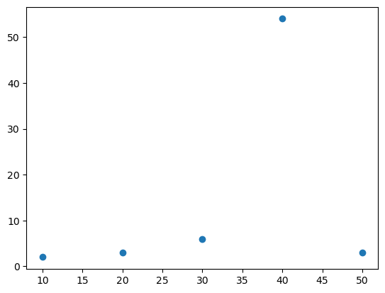

```python
plt.scatter(x,y)
```

```python
x1 = [34.5,45.6,56.7,67.8,78.9,89.0,65.4,55.4,34,89.0,32.3,36.9]
y1 = [45,56.7,34.5,78.9,89.0,12.3,16.9,63,28,34.5,45.6,56.7]
```

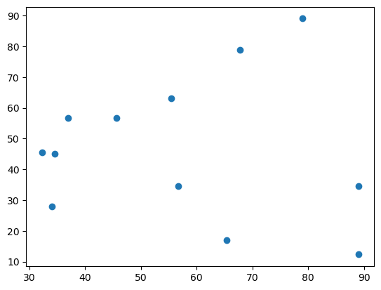

```python
plt.scatter(x1,y1)
```

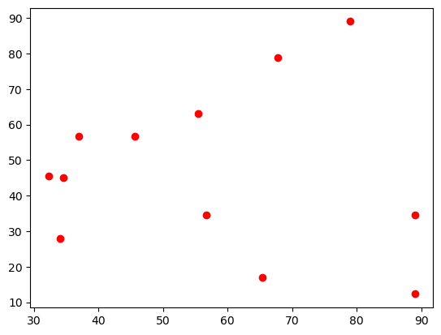

```python
plt.scatter(x1,y1,color='r')
```

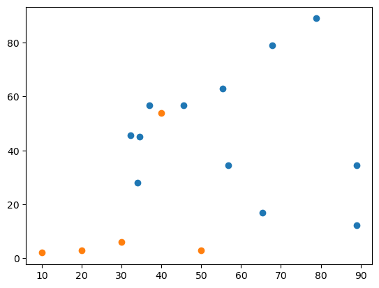

```python
plt.scatter(x1,y1)
plt.scatter(x,y)
```

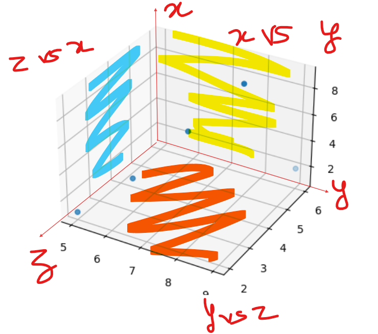

Example:

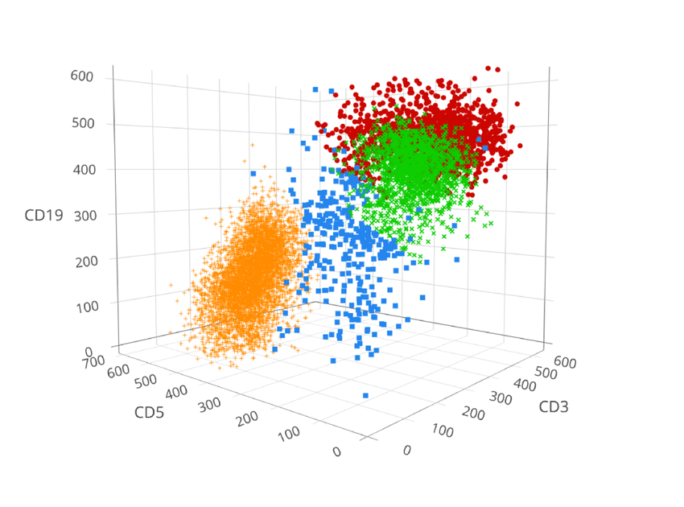

```python
q = [5,6,7,8,9]
r = [2,3,4,5,6]
z = [1,3,6,9,2]
```

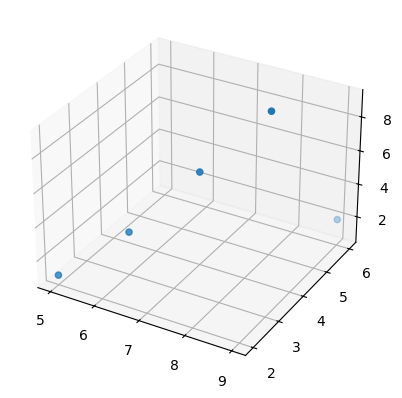

```python
fig = plt.figure()
ax = fig.add_subplot(projection='3d')
ax.scatter(q,r,z)
plt.show()
```

## Histogram are used to understand the distribution of continuous data

Data Distributions like Normal Distribution/Guassian Distribution, Skewed Distribution

```python
d = [1,2,2,3,3,3,4,4,4,4,5,5,5,5,5]
```

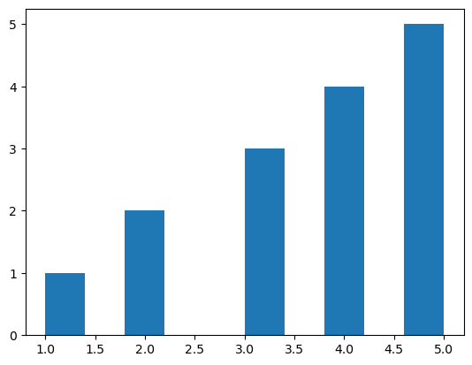

```python
plt.hist(d)
plt.show()
```

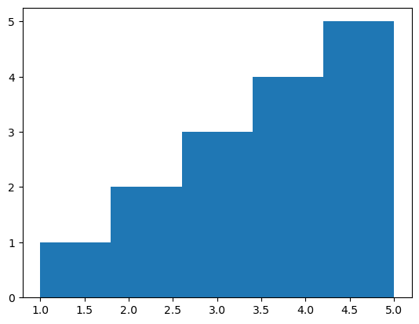

```python
plt.hist(d,bins=5)
plt.show()
```

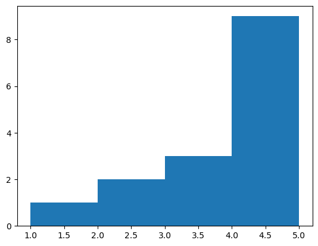

```python
plt.hist(d,bins=4)
plt.show()
```

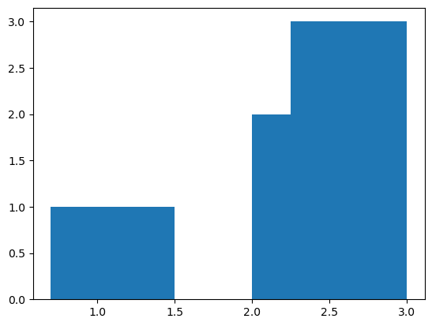

```python
bins1 = [0.7,1.5,2,2.25,3]
plt.hist(d,bins=bins1)
plt.show()
```

## BoxPlots helps in identifying outliers in data

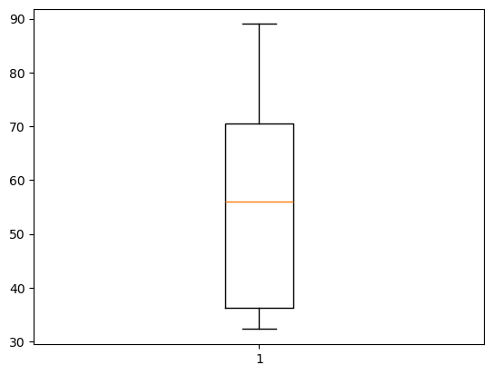

```python
plt.boxplot(x1)
plt.show()
```

```python
y1
```

```
[45, 56.7, 34.5, 78.9, 89.0, 12.3, 16.9, 63, 28, 34.5, 45.6, 56.7]
```

```python
y1.append(1)
```

```python
y1.append(0.25)
```

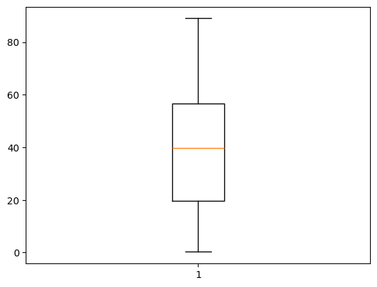

```python
plt.boxplot(y1)
plt.show()
```

## Heatmaps are useful in understanding correlations among the data

```python
import numpy as np
data = np.random.rand(10,10)
data
```

```
array([[0.63975819, 0.62152772, 0.92257703, 0.99626771, 0.85838311,
        0.37727741, 0.63659767, 0.69698443, 0.58613556, 0.89912457],
       [0.45550514, 0.92339788, 0.4803777 , 0.70736237, 0.09629361,
        0.42833627, 0.26750822, 0.97200127, 0.27821874, 0.0016116 ],
       [0.35871313, 0.70044898, 0.75653354, 0.65457161, 0.27883639,
        0.96980496, 0.94038025, 0.40399276, 0.33407914, 0.90222921],
       [0.88932267, 0.32750304, 0.74400256, 0.41159565, 0.41034213,
        0.72446371, 0.11282807, 0.16887027, 0.13178332, 0.97738482],
       [0.57590665, 0.08880602, 0.77969467, 0.27354495, 0.56608301,
        0.05259823, 0.59815248, 0.72534852, 0.98838277, 0.00247952],
       [0.6562947 , 0.81992204, 0.1486885 , 0.89665775, 0.3772009 ,
        0.05830948, 0.57506199, 0.283464  , 0.18162141, 0.22647999],
       [0.0912062 , 0.55358176, 0.05611345, 0.92820151, 0.83287228,
        0.82584265, 0.457637  , 0.45458623, 0.84235527, 0.41446031],
       [0.08266962, 0.9526817 , 0.77331426, 0.58256629, 0.22674121,
        0.25424886, 0.26319886, 0.61158137, 0.2251709 , 0.93727268],
       [0.01782736, 0.13081919, 0.52670863, 0.7824055 , 0.29581621,
        0.27360342, 0.45999401, 0.36356268, 0.65754904, 0.3886487 ],
       [0.71055084, 0.60406806, 0.6906752 , 0.5015148 , 0.31201933,
        0.53259134, 0.18820095, 0.3550374 , 0.97599285, 0.60545377]])
```

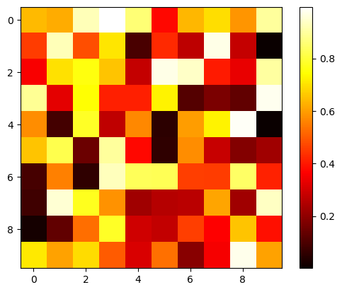

```python
plt.imshow(data,cmap='hot',interpolation='nearest')
plt.colorbar()
```

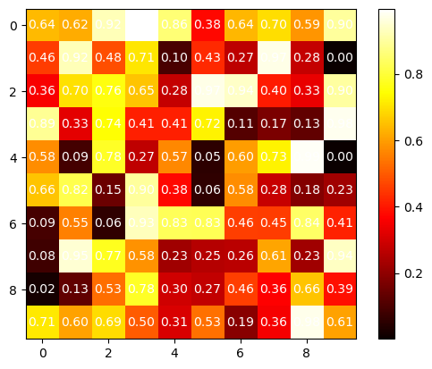

```python
plt.imshow(data, cmap='hot', interpolation='nearest')
plt.colorbar()

# Add annotations
rows, cols = data.shape
for i in range(rows):
    for j in range(cols):
        plt.text(j, i, f"{data[i, j]:.2f}", ha='center', va='center', color='white')

plt.show()
```

## Contour Plots are used to display 3d data on a 2D plane.

```python
x2 = np.linspace(-3,3,100)
y2 = np.linspace(-3,3,100)
```

```python
x2
```

```
array([-3.        , -2.93939394, -2.87878788, -2.81818182, -2.75757576,
       -2.6969697 , -2.63636364, -2.57575758, -2.51515152, -2.45454545,
       -2.39393939, -2.33333333, -2.27272727, -2.21212121, -2.15151515,
       -2.09090909, -2.03030303, -1.96969697, -1.90909091, -1.84848485,
       -1.78787879, -1.72727273, -1.66666667, -1.60606061, -1.54545455,
       -1.48484848, -1.42424242, -1.36363636, -1.3030303 , -1.24242424,
       -1.18181818, -1.12121212, -1.06060606, -1.        , -0.93939394,
       -0.87878788, -0.81818182, -0.75757576, -0.6969697 , -0.63636364,
       -0.57575758, -0.51515152, -0.45454545, -0.39393939, -0.33333333,
       -0.27272727, -0.21212121, -0.15151515, -0.09090909, -0.03030303,
        0.03030303,  0.09090909,  0.15151515,  0.21212121,  0.27272727,
        0.33333333,  0.39393939,  0.45454545,  0.51515152,  0.57575758,
        0.63636364,  0.6969697 ,  0.75757576,  0.81818182,  0.87878788,
        0.93939394,  1.        ,  1.06060606,  1.12121212,  1.18181818,
        1.24242424,  1.3030303 ,  1.36363636,  1.42424242,  1.48484848,
        1.54545455,  1.60606061,  1.66666667,  1.72727273,  1.78787879,
        1.84848485,  1.90909091,  1.96969697,  2.03030303,  2.09090909,
        2.15151515,  2.21212121,  2.27272727,  2.33333333,  2.39393939,
        2.45454545,  2.51515152,  2.57575758,  2.63636364,  2.6969697 ,
        2.75757576,  2.81818182,  2.87878788,  2.93939394,  3.        ])
```

```python
# Convert the data into rectangular grid
X,Y = np.meshgrid(x2,y2)
```

```python
X
```

```
array([[-3.        , -2.93939394, -2.87878788, ...,  2.87878788,
         2.93939394,  3.        ],
       [-3.        , -2.93939394, -2.87878788, ...,  2.87878788,
         2.93939394,  3.        ],
       [-3.        , -2.93939394, -2.87878788, ...,  2.87878788,
         2.93939394,  3.        ],
       ...,
       [-3.        , -2.93939394, -2.87878788, ...,  2.87878788,
         2.93939394,  3.        ],
       [-3.        , -2.93939394, -2.87878788, ...,  2.87878788,
         2.93939394,  3.        ],
       [-3.        , -2.93939394, -2.87878788, ...,  2.87878788,
         2.93939394,  3.        ]])
```

```python
Z = np.sin(X)*np.cos(Y)
Z
```

```
array([[ 0.13970775,  0.19881399,  0.25719019, ..., -0.25719019,
        -0.19881399, -0.13970775],
       [ 0.13824503,  0.19673243,  0.25449744, ..., -0.25449744,
        -0.19673243, -0.13824503],
       [ 0.13627467,  0.19392848,  0.25087018, ..., -0.25087018,
        -0.19392848, -0.13627467],
       ...,
       [ 0.13627467,  0.19392848,  0.25087018, ..., -0.25087018,
        -0.19392848, -0.13627467],
       [ 0.13824503,  0.19673243,  0.25449744, ..., -0.25449744,
        -0.19673243, -0.13824503],
       [ 0.13970775,  0.19881399,  0.25719019, ..., -0.25719019,
        -0.19881399, -0.13970775]])
```

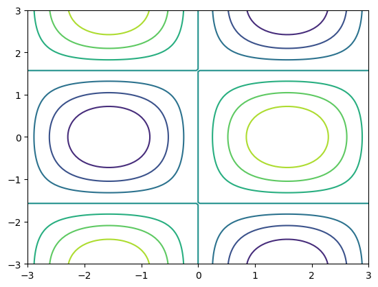

```python
plt.contour(X,Y,Z)
```